# EDA on retail data

```python
import pandas as pd
import matplotlib.pyplot as plt
import seaborn as sns
```

```python
retail_data = pd.read_csv('retail_sales_dataset.csv')
```

```python
print(retail_data.head())
```

```
   Transaction ID        Date Customer ID  Gender  Age Product Category  \
0               1  2023-11-24     CUST001    Male   34           Beauty
1               2  2023-02-27     CUST002  Female   26         Clothing
2               3  2023-01-13     CUST003    Male   50      Electronics
3               4  2023-05-21     CUST004    Male   37         Clothing
4               5  2023-05-06     CUST005    Male   30           Beauty

   Quantity  Price per Unit  Total Amount
0         3              50           150
1         2             500          1000
2         1              30            30
3         1             500           500
4         2              50           100
```

```python
print(retail_data.isnull().sum())
```

```
Transaction ID      0
Date                0
Customer ID         0
Gender              0
Age                 0
Product Category    0
Quantity            0
Price per Unit      0
Total Amount        0
dtype: int64
```

```python
retail_data.drop_duplicates(inplace=True)
```

```python
basic_stats = retail_data.describe()
print(basic_stats)
```

```
       Transaction ID         Age     Quantity  Price per Unit  Total Amount
count     1000.000000  1000.00000  1000.000000     1000.000000   1000.000000
mean       500.500000    41.39200     2.514000      179.890000    456.000000
std        288.819436    13.68143     1.132734      189.681356    559.997632
min          1.000000    18.00000     1.000000       25.000000     25.000000
25%        250.750000    29.00000     1.000000       30.000000     60.000000
50%        500.500000    42.00000     3.000000       50.000000    135.000000
75%        750.250000    53.00000     4.000000      300.000000    900.000000
max       1000.000000    64.00000     4.000000      500.000000   2000.000000
```

# time serie analysis

```python
# Data Preprocessing
retail_data['Date'] = pd.to_datetime(retail_data['Date'])
retail_data.set_index('Date', inplace=True)
```

```python
 # Aggregate Data (assuming monthly aggregation)
monthly_sales = retail_data.resample('M').sum(numeric_only=True)  # Explicitly set numeric_only=True
```

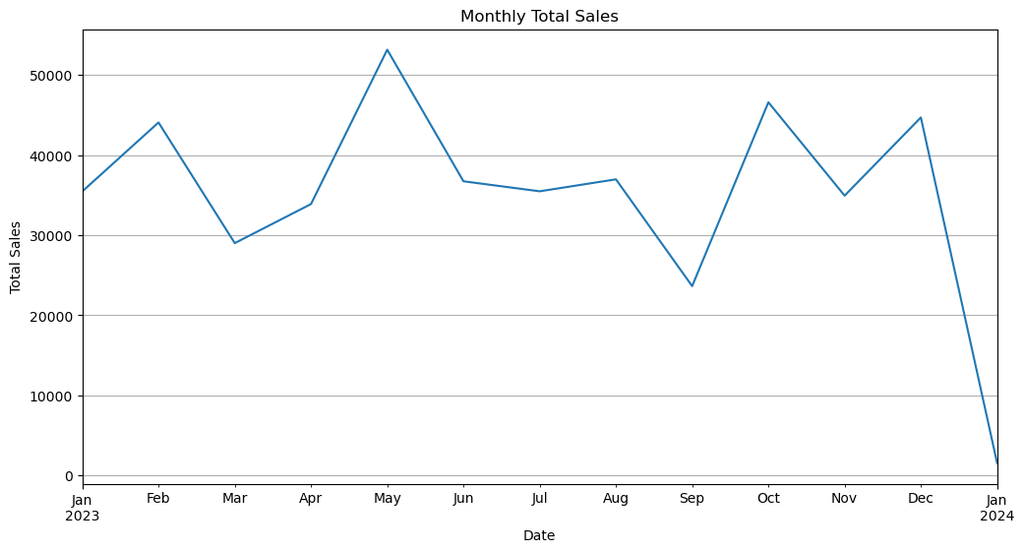

```python
# Visualize Trends
plt.figure(figsize=(12, 6))
monthly_sales['Total Amount'].plot()
plt.title('Monthly Total Sales')
plt.xlabel('Date')
plt.ylabel('Total Sales')
plt.grid(True)
plt.show()
```

# customer and product analysis

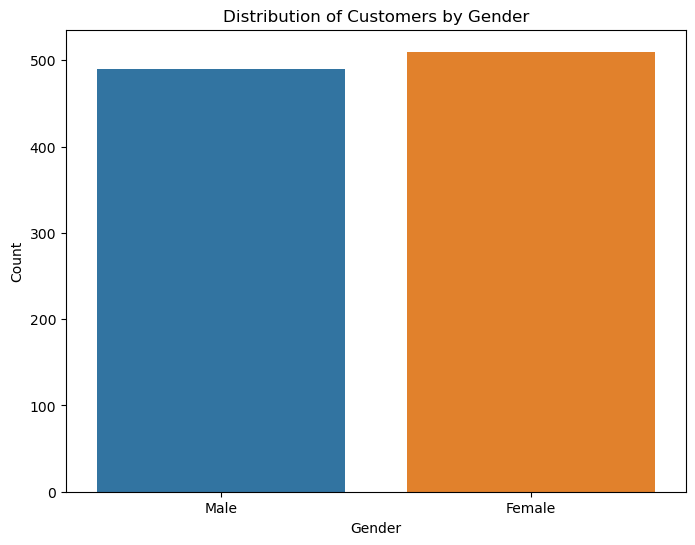

```python
# Customer Demographics Analysis
# Distribution of customers by gender
plt.figure(figsize=(8, 6))
sns.countplot(x='Gender', data=retail_data)
plt.title('Distribution of Customers by Gender')
plt.xlabel('Gender')
plt.ylabel('Count')
plt.show()
```

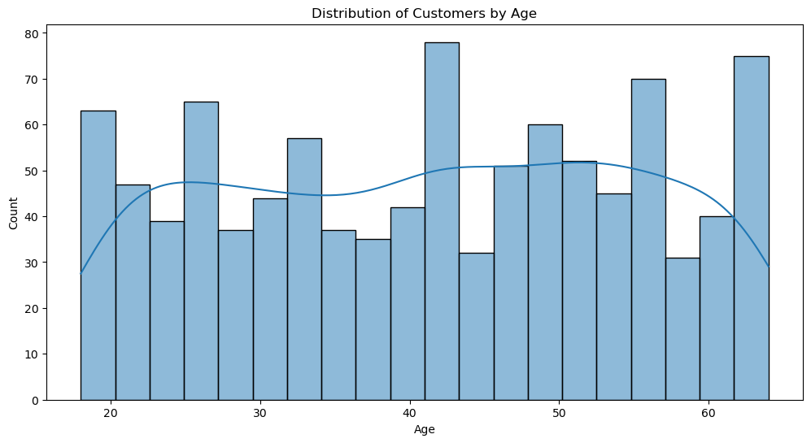

```python
# Distribution of customers by age
plt.figure(figsize=(12, 6))
sns.histplot(retail_data['Age'], bins=20, kde=True)
plt.title('Distribution of Customers by Age')
plt.xlabel('Age')
plt.ylabel('Count')
plt.show()
```

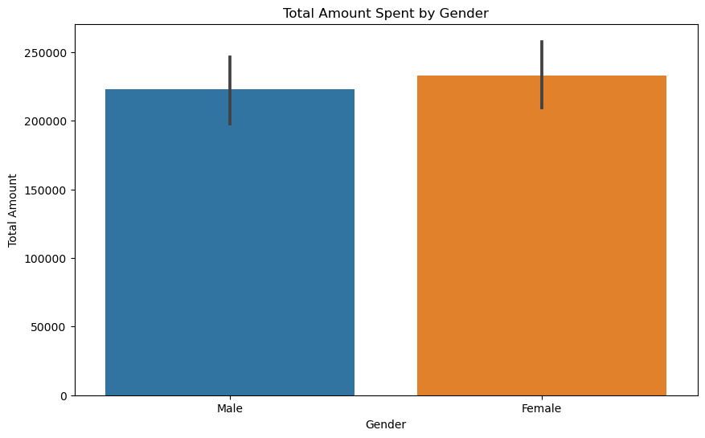

```python
# Purchasing Behavior Analysis
# Total amount spent by gender
plt.figure(figsize=(10, 6))
sns.barplot(x='Gender', y='Total Amount', data=retail_data, estimator=sum)
plt.title('Total Amount Spent by Gender')
plt.xlabel('Gender')
plt.ylabel('Total Amount')
plt.show()
```

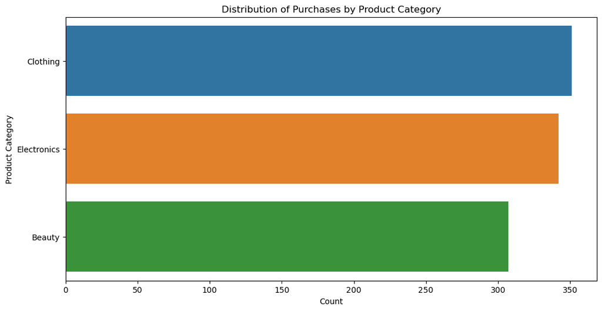

```python
# Product Analysis
# Distribution of purchases by product category
plt.figure(figsize=(12, 6))
sns.countplot(y='Product Category', data=retail_data, order=retail_data['Product Category'].value_counts().index)
plt.title('Distribution of Purchases by Product Category')
plt.xlabel('Count')
plt.ylabel('Product Category')
plt.show()
```

```python
# Top selling product categories
top_categories = retail_data['Product Category'].value_counts().head(5)
print("Top 5 Selling Product Categories:")
print(top_categories)
```

```
Top 5 Selling Product Categories:
Clothing       351
Electronics    342
Beauty         307
Name: Product Category, dtype: int64
```

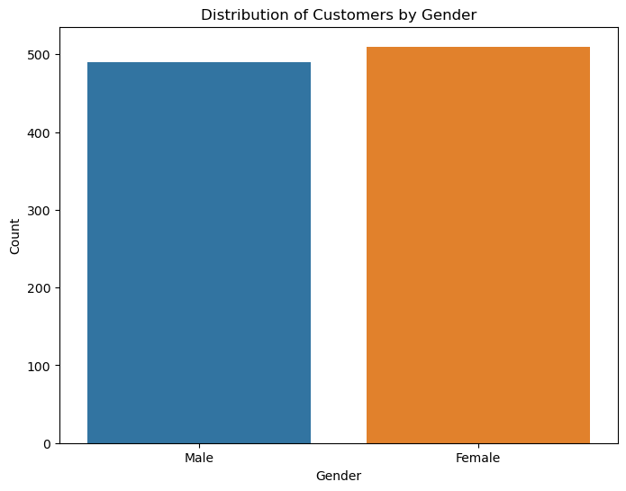

```python
# Bar chart: Distribution of customers by gender
plt.figure(figsize=(8, 6))
sns.countplot(x='Gender', data=retail_data)
plt.title('Distribution of Customers by Gender')
plt.xlabel('Gender')
plt.ylabel('Count')
plt.show()
```

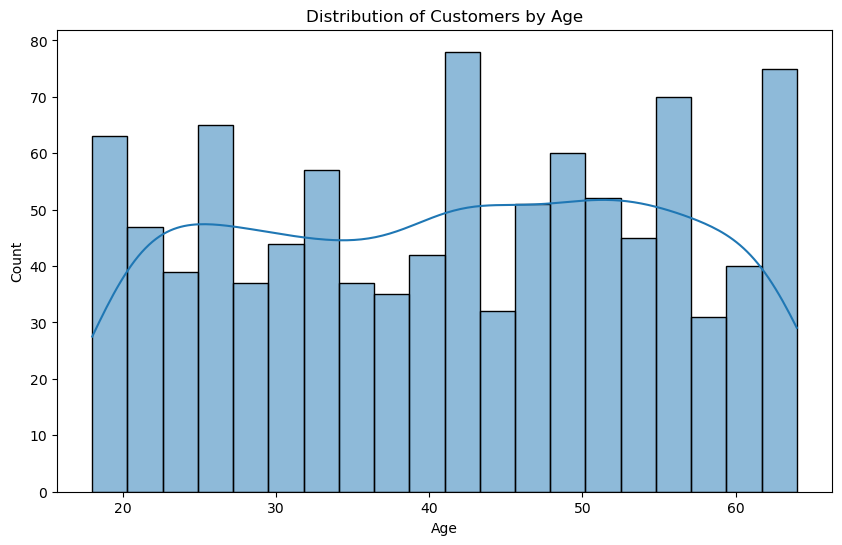

```python
# Line plot: Distribution of customers by age
plt.figure(figsize=(10, 6))
sns.histplot(retail_data['Age'], bins=20, kde=True)
plt.title('Distribution of Customers by Age')
plt.xlabel('Age')
plt.ylabel('Count')
plt.show()
```

# visualization:purchasing behaviour

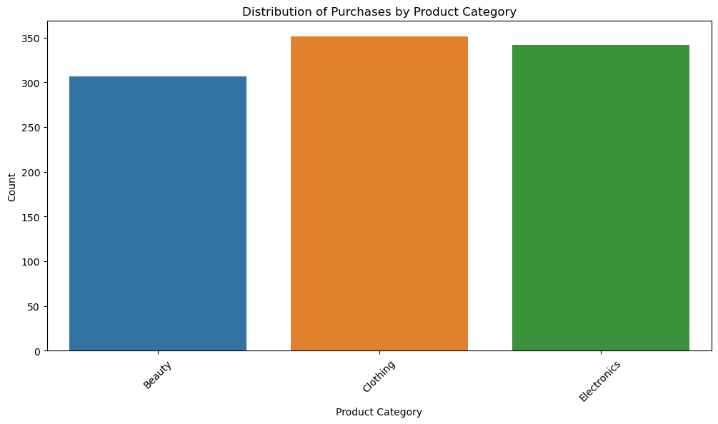

```python
# Bar chart: Distribution of purchases by product category
plt.figure(figsize=(12, 6))
sns.countplot(x='Product Category', data=retail_data)
plt.title('Distribution of Purchases by Product Category')
plt.xlabel('Product Category')
plt.ylabel('Count')
plt.xticks(rotation=45)
plt.show()
```

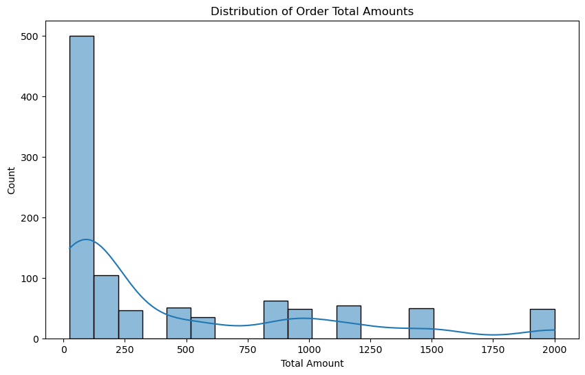

```python
# Line plot: Distribution of order total amounts
plt.figure(figsize=(10, 6))
sns.histplot(retail_data['Total Amount'], bins=20, kde=True)
plt.title('Distribution of Order Total Amounts')
plt.xlabel('Total Amount')
plt.ylabel('Count')
plt.show()
```

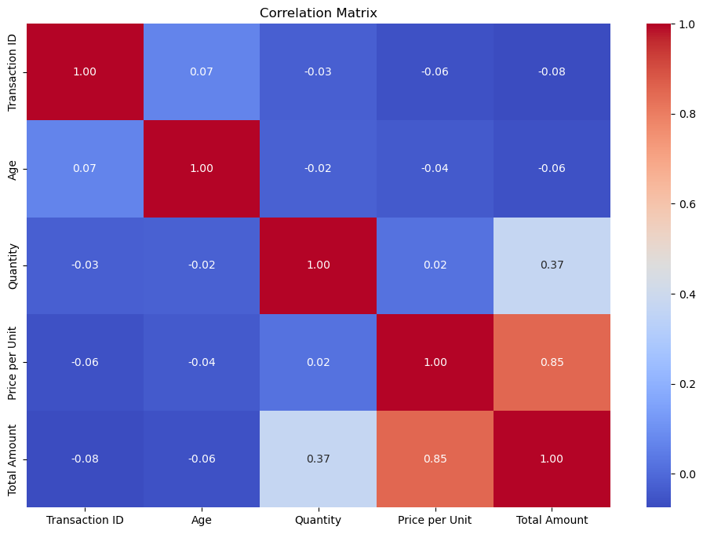

```python
# Heatmap: Correlation matrix
correlation_matrix = retail_data.corr()
plt.figure(figsize=(12, 8))
sns.heatmap(correlation_matrix, annot=True, cmap='coolwarm', fmt='.2f')
plt.title('Correlation Matrix')
plt.show()
```

# recommendations

Targeted Marketing Strategies:

Utilize customer demographics insights to tailor marketing strategies. For example, if there is a significant gender difference in purchasing behavior, consider designing marketing campaigns that resonate with each gender group. Product Assortment Optimization:

Analyze the popularity of product categories and adjust the product assortment accordingly. Focus on promoting or expanding product categories that have high demand. Customer Engagement:

Leverage insights on customer preferences and purchasing behavior to enhance customer engagement. Offer personalized recommendations and promotions to incentivize repeat purchases. Seasonal Promotions:

Identify seasonal trends in purchasing behavior and launch targeted promotions or seasonal campaigns to capitalize on peak demand periods. Customer Retention Strategies:

Implement loyalty programs or rewards systems to encourage customer loyalty and repeat purchases. Offer special discounts or perks to frequent customers. Operational Efficiency:

Optimize inventory management and supply chain operations based on product popularity and sales trends. Ensure adequate stock levels for high-demand products while minimizing excess inventory for slow-moving items. Customer Experience Enhancement:

Enhance the overall customer experience by streamlining the purchasing process and offering convenient payment options. Focus on providing excellent customer service to drive customer satisfaction and loyalty. Market Expansion Opportunities:

Explore opportunities for market expansion based on customer demographics and geographic distribution. Identify potential target markets or regions with untapped customer segments. Data-Driven Decision Making:

Continuously monitor and analyze customer data to identify emerging trends and opportunities. Use data-driven insights to make informed business decisions and adapt strategies as needed. Competitive Analysis:

Conduct competitive analysis to benchmark performance against industry peers and identify areas for improvement. Stay informed about market trends and competitor strategies to maintain a competitive edge.